# Impact of Severe Weather Events on Public Health and Economy in the United States

Joe Cannon

October 12, 2015

##### Synopsis

In this report, the goal is to analyze the impact of different weather events on public health and economy based on the storm database collected from the U.S. National Oceanic and Atmospheric Administration’s (NOAA) from 1950 - 2011. The data used will be estimates of:

-Fatalities, and injuries to caclulate damage with regards to population health -Property and crop damage to caclulate damage with regards to economic impact

The work that I did for this project is available at https://github.com/jpcannon/RepData_PeerAssessment2

### Load Libraries

```r
suppressWarnings(suppressMessages(library(ggplot2)))
suppressWarnings(suppressMessages(library(dplyr)))
suppressWarnings(suppressMessages(library(lubridate)))
suppressWarnings(suppressMessages(library(gridExtra)))
suppressWarnings(suppressMessages(library(grid)))
suppressWarnings(suppressMessages(library(gtable)))
suppressWarnings(suppressMessages(library(scales)))
```

Data Processing First, we check to make sure the data is present, if not download it. Then we decompress it so we can proess it.

```r
if (!"stormdata.csv.bz2" %in% tolower(dir("./"))) {
    print("hhhh")
    download.file("http://d396qusza40orc.cloudfront.net/repdata%2Fdata%2FStormData.csv.bz2", destfile = "stormdata.csv.bz2")
}
stormdata <- read.table("stormdata.csv.bz2",
                       header = T,quote="\"", sep=",",na.strings = NA)
```

Information about the data.

```r
str(stormdata)
```

```
## 'data.frame':    902297 obs. of  37 variables:
##  $ STATE__   : num  1 1 1 1 1 1 1 1 1 1 ...
##  $ BGN_DATE  : Factor w/ 16335 levels "1/1/1966 0:00:00",..: 6523 6523 4242 11116 2224 2224 2260 383 3980 3980 ...
##  $ BGN_TIME  : Factor w/ 3608 levels "00:00:00 AM",..: 272 287 2705 1683 2584 3186 242 1683 3186 3186 ...
##  $ TIME_ZONE : Factor w/ 22 levels "ADT","AKS","AST",..: 7 7 7 7 7 7 7 7 7 7 ...
##  $ COUNTY    : num  97 3 57 89 43 77 9 123 125 57 ...
##  $ COUNTYNAME: Factor w/ 29601 levels "","5NM E OF MACKINAC BRIDGE TO PRESQUE ISLE LT MI",..: 13513 1873 4598 10592 4372 10094 1973 23873 24418 4598 ...
##  $ STATE     : Factor w/ 72 levels "AK","AL","AM",..: 2 2 2 2 2 2 2 2 2 2 ...
##  $ EVTYPE    : Factor w/ 985 levels "   HIGH SURF ADVISORY",..: 834 834 834 834 834 834 834 834 834 834 ...
##  $ BGN_RANGE : num  0 0 0 0 0 0 0 0 0 0 ...
##  $ BGN_AZI   : Factor w/ 35 levels "","  N"," NW",..: 1 1 1 1 1 1 1 1 1 1 ...
##  $ BGN_LOCATI: Factor w/ 54429 levels "","- 1 N Albion",..: 1 1 1 1 1 1 1 1 1 1 ...
##  $ END_DATE  : Factor w/ 6663 levels "","1/1/1993 0:00:00",..: 1 1 1 1 1 1 1 1 1 1 ...
##  $ END_TIME  : Factor w/ 3647 levels ""," 0900CST",..: 1 1 1 1 1 1 1 1 1 1 ...
##  $ COUNTY_END: num  0 0 0 0 0 0 0 0 0 0 ...
```

[output cut: 23 more lines]

Set the data types I want to use.

```r
stormdata$BGN_DATE <- as.Date(stormdata$BGN_DATE,format="%m/%d/%Y")
stormdata$BGN_TIME <- as.character(stormdata$BGN_TIME)
stormdata$EVTYPE   <- as.character(stormdata$EVTYPE)
bn12hr <- length(stormdata[grep("AM|PM",stormdata$BGN_TIME),]$BGN_TIME)
```

##### Now we have to clean up the begin dates. Even though they are suppose to enter the time in 24hr format; we noticed that 653530 times have been entered in 12hr format. So we are going to convert those to 24hr format.

#### NOTE: The Ending times are so sparse and in such bad shape that it does not make sense to work with that data at this point.

Next we convert the 12hr formats to 24hr HHMM format.

Split out the times that have an AM or PM in them from the 24hr formated times.

```r
AMPMData <-stormdata[grepl("[AM]|[PM]",stormdata$BGN_TIME),]
t2 <-stormdata[!(grepl("[AM]|[PM]",stormdata$BGN_TIME)),]
n12rows <- nrow(AMPMData)
n24rows <- nrow(t2)
pamrows <- (n12rows/(n12rows+n24rows)) *100
```

There were 653530 formated as 12hr, and 248767 rows in 24 hour format. About 72.429588% of the observations were in 12hr format.

Convert the 12hr times to 24hr format.

```r
AMPMData$NBGN_TIME <- paste0(substr(strptime(AMPMData$BGN_TIME, "%I:%M:%S %p" ),12,13),                                   substr(strptime(AMPMData$BGN_TIME, "%I:%M:%S %p" ),15,16))
AMPMData[grepl("NA",AMPMData$NBGN_TIME),]$NBGN_TIME<- paste0(substr(AMPMData[grepl("NA",AMPMData$NBGN_TIME),]$BGN_TIME,1,2),substr(AMPMData[grepl("NA",AMPMData$NBGN_TIME),]$BGN_TIME,4,5))
AMPMData$BGN_TIME <-AMPMData$NBGN_TIME
AMPMData <- select(AMPMData,-(NBGN_TIME))
```

Recombine the datasets

```r
stormdata <- rbind(t2,AMPMData)
stormdata$BGN_TIME <-  sprintf("%04s", stormdata$BGN_TIME)
```

Identify the boundry years

```r
#Identify boundry years
lastyear <- max(year(stormdata$BGN_DATE))
firstyear <- min(year(stormdata$BGN_DATE))
```

The events in the database start in the year 1950 and end in 2011. The spread is as follows.

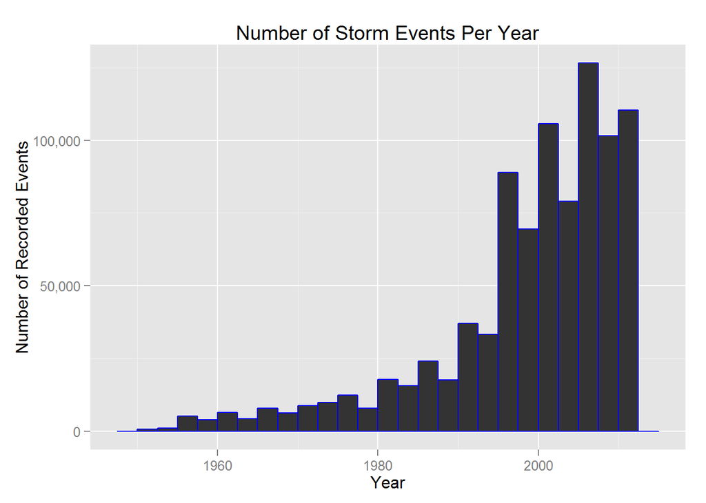

```r
ggplot(stormdata, aes(x = year(stormdata$BGN_DATE))) +
        geom_histogram(color="blue",binwidth=2.5) +
        scale_y_continuous(labels = comma)+
        ggtitle("Number of Storm Events Per Year")+
        xlab("Year")+
        ylab("Number of Recorded Events")
```

#### Trim the data to a representitive subset.

I decided to trim down to the last 20 years. Events occurring before then are not as relevant as technologies such as storm warnings, architectural integrity have dramatically improved. Also data entered in prior to 1991 is much more sparse and suspect in coding. It should be noted that during my experiments I noted changing the cutoff date above 1991 alters the top economic event as shown

- All Years -> Tornado
- 1991(last 20 years) -> Tornado
- 1995(Big jump in avail data) -> Flash Flood
- 1996(last 15 years) -> TSTM Wind
- 2001(last 10 years) -> Flash Flood

Personal cost remained consistant with Tornados being the #1 cause of injury/death by a hefty margin. This point came up in the discussion forums.

So we will trim the data down to the last 20years and only the varibles that we are uing in the anlysis.

```r
cstormdata <- stormdata[which(year(stormdata$BGN_DATE)>=1991),]%>%
             select(BGN_DATE,BGN_TIME,EVTYPE,INJURIES,FATALITIES,PROPDMG,CROPDMG)
cstormdata$EVTYPE <- as.character(cstormdata$EVTYPE)
nrowcstorm <- nrow(cstormdata)
ncolcstorm <- ncol(cstormdata)
```

Now we are working with 740794 observations of 7 variables.

A summary of the data that we will be analizng is.

```r
summary(cstormdata)
```

```
##     BGN_DATE            BGN_TIME            EVTYPE
##  Min.   :1991-01-10   Length:740794      Length:740794
##  1st Qu.:1998-11-10   Class :character   Class :character
##  Median :2004-05-07   Mode  :character   Mode  :character
##  Mean   :2003-07-13
##  3rd Qu.:2008-06-08
##  Max.   :2011-11-30
##     INJURIES          FATALITIES          PROPDMG           CROPDMG
##  Min.   :   0.000   Min.   :  0.0000   Min.   :   0.00   Min.   :  0.00
##  1st Qu.:   0.000   1st Qu.:  0.0000   1st Qu.:   0.00   1st Qu.:  0.00
##  Median :   0.000   Median :  0.0000   Median :   0.00   Median :  0.00
##  Mean   :   0.097   Mean   :  0.0148   Mean   :  12.41   Mean   :  1.86
##  3rd Qu.:   0.000   3rd Qu.:  0.0000   3rd Qu.:   1.00   3rd Qu.:  0.00
##  Max.   :1568.000   Max.   :583.0000   Max.   :5000.00   Max.   :990.00
```

Next we calculate the costs in injury/fatalities per event.

```r
personalcost_event <- aggregate(cbind(INJURIES,FATALITIES,INJURIES+FATALITIES)~EVTYPE , cstormdata, sum, na.action=na.omit)
colnames(personalcost_event) <- c("EVTYPE","INJURIES","FATALITIES","TOTALPC")
personalcost_event$EVTYPE = as.character(personalcost_event$EVTYPE)
TPI <- head(personalcost_event[order(-personalcost_event$TOTALPC),],7)
colnames(TPI) <- c("Event","Injuries","Fatalities","Total Death/Fatalities")
```

As well as calculate the costs in economic costs per event.

```r
economiccost_event <- aggregate(cbind(PROPDMG,CROPDMG,PROPDMG+CROPDMG)~EVTYPE , cstormdata, sum, na.action=na.omit)
colnames(economiccost_event) <- c("EVTYPE","PROPDMG","CROPDMG","TOTALEC")
economiccost_event$EVTYPE = as.character(economiccost_event$EVTYPE)
TEC <- head(economiccost_event[order(-economiccost_event$TOTALEC),],7)
colnames(TEC) <- c("Event","Prop Damage","Crop Damage","Total $ Damage")
```

Combine the two cost types

```r
tt <- merge(TEC,TPI)
tt$"Economic Damage RANK" <- rank(-tt$`Total $ Damage`)
tt$"Personal Inj/Death Rank"<- rank(-tt$`Total Death/Fatalities`)
tt <-arrange(tt,tt$"Personal Inj/Death Rank",tt$"Economic Damage RANK")
```

Display in a meaningful table with respective ranking

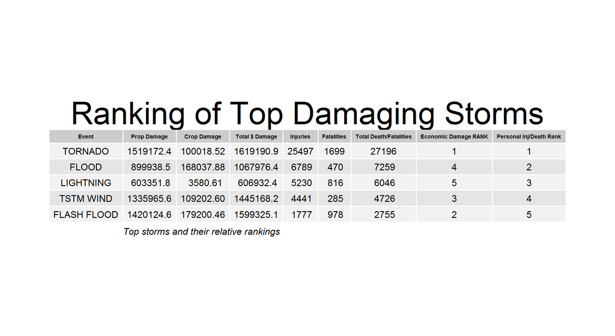

```r
mytheme <- gridExtra::ttheme_default(
    core = list(fg_params=list(cex = 1)),
    colhead = list(fg_params=list(cex = .6)),
    rowhead = list(fg_params=list(cex = .6)))

table <- gridExtra::tableGrob(tt, theme = mytheme,rows=NULL)
title <- textGrob("Ranking of Top Damaging Storms",gp=gpar(fontsize=40))
footnote <- textGrob("Top storms and their relative rankings", x=0, hjust=0,
                     gp=gpar( fontface="italic"))
padding <- unit(1,"line")
table <- gtable_add_rows(table,
                         heights = grobHeight(title) + padding,
                         pos = 0)
table <- gtable_add_rows(table,
                         heights = grobHeight(footnote)+ padding)
table <- gtable_add_grob(table, list(title, footnote),
                         t=c(1, nrow(table)), l=c(1,2),
                         r=ncol(table))

grid.newpage()
grid.draw(table)
```

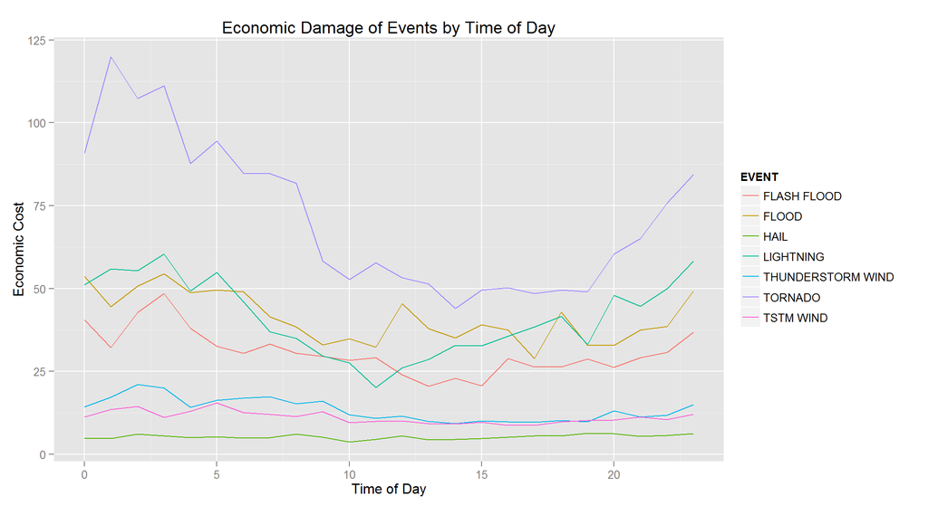

```r
TopStorms <- cstormdata[which(cstormdata$EVTYPE %in% TEC$Event & substr(cstormdata$BGN_TIME,1,2)!="24"),]
TopStorms_TimeTrend <- aggregate(cbind(PROPDMG+CROPDMG,INJURIES+FATALITIES)~as.integer(substr(BGN_TIME,1,2))+EVTYPE, TopStorms, mean)

colnames(TopStorms_TimeTrend) <- c("TIME","EVENT","TECODMG","TPERDMG")

 ggplot(TopStorms_TimeTrend, aes(x=TIME, y=TECODMG,colour = EVENT)) +
  geom_line()+
  ggtitle("Economic Damage of Events by Time of Day")+
     xlab("Time of Day")+
     ylab("Economic Cost")
```